# Vignette of AeRobiology

# Function plot_summary()

The function **plot_summary()** is to plot the pollen data during several seasons. Also to plot the averaged pollen season over the study period. It is possible to plot the relative abundance per day and smoothing the pollen season by calculating a moving average. The main arguments are:

- **data**: A `data.frame` object. This data.frame should include a first column in “Date” format and the rest of columns in “numeric” format belonging to each pollen type by column.
- **pollen:** A `character` string with the name of the particle to show. This character must match with the name of a column in the input database. This is a mandatory argument.
- **mave:** An `integer` value specifying the order of the moving average applied to the data. By default, `mave = 1`.
- **normalized:** A `logical` value specifying if the visualization shows real pollen data (`normalized = FALSE`) or the percentage of every day over the whole pollen season (`normalized = TRUE`). By default, `normalized = FALSE`.
- **axisname:** A `character` string specifying the title of the y axis. By default, `axisname = "Pollen grains / m3"`
- Others…

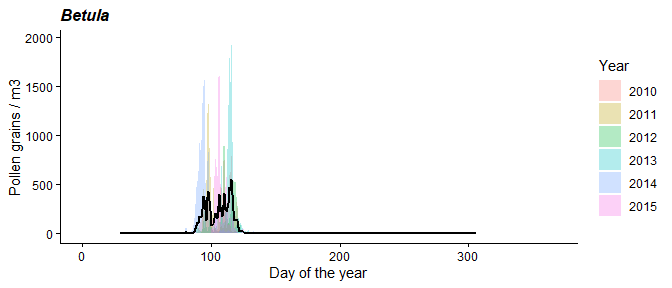

```r
plot_summary(munich_pollen, pollen = "Betula")
```

In some cases the user may want to reduce the “noise” of the daily values by **calculating moving means** (E.g.: 5 days moving mean; `mave = 5`):

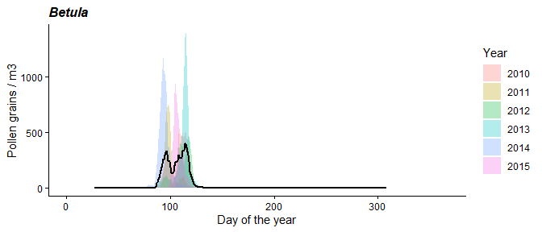

```r
plot_summary(munich_pollen, pollen = "Betula", mave = 5)
```

You might be also interested in representing as background the **percentage** each day suppose to the main pollen season (`normalized = TRUE`):

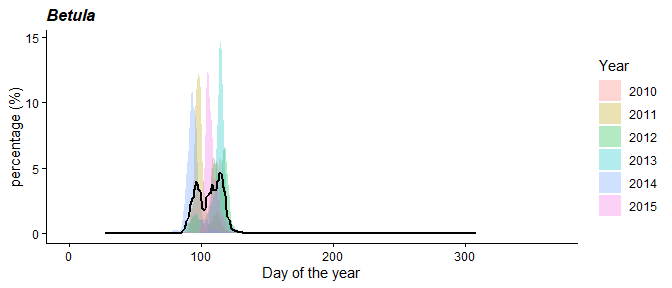

```r
plot_summary(munich_pollen, pollen = "Betula", mave = 5, normalized = TRUE)
```

**interpollen() function** is integrated in this function. Consult the “help” section of this function to use it.

# Function plot_normsummary()

The function **plot_normsummary()** has been designed to plot the pollen data amplitude during several seasons: daily average pollen concentration over the study period, maximum pollen concentration of each day over the study period and minimum pollen concentration of each day value over the study period. It is possible to plot the relative abundance per day and smoothing the pollen season by calculating a moving average. The main arguments similar to **plot_summary()**, but as a result **you will obtain the the max-min range of the study period** instead of the values for every year.

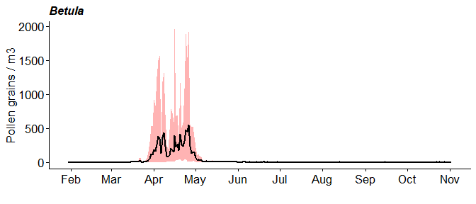

```r
plot_normsummary(munich_pollen, pollen = "Betula", color.plot = "red")
```

The **maximum values** are marked in **red** and the **minimum values in white**. The **average** is the **black line**.

Of course, you can change the color (`color.plot` argument):

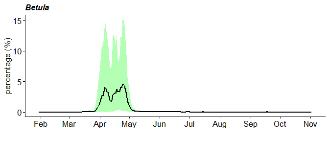

```r
plot_normsummary(munich_pollen, pollen = "Betula", color.plot = "green", mave = 5, normalized = TRUE)
```

**interpollen() function** is integrated in this function. Consult the “help” section of this function to use it.

# Function analyse_trend()

The function **analyse_trend()** has been created to calculate the main seasonal indexes of the pollen season (“Start Date”, “Peak Date”, “End Date” and “Pollen Integral”), as well as **trends analysis** of those parameters over the seasons. It is a summary dot plot showing the distribution of the main seasonal indexes over the years.

The results can also be stored in two folders termed **“plot_AeRobiology”** and **“table_AeRobiology”**, which will be created in your working directory (only if `export.result = FALSE` & `export.plot = FALSE`). You can decide which result to be returned from the function by setting the argument **result**: *result = “table”* or *result = “plot”*.

The function allows you to decide if you want to interpolate the data or not, by the argument **`interpolation`**, it also allows you to select the interpolation method by the argument **`int.method`**. Furthermore, it allows you to select the pollen season definition method, by the argument **`method`** and additional arguments for the function **calculate_ps()**. Some arguments about the visualization are:

- **split**: A `logical` argument. If `split = TRUE`, the plot is separated in two according to the nature of the variables (i.e. dates or pollen concentrations). **This argument was a solution to reduce the scale of the x-axis when “total pollen”” variable has a very high/low slope**. By default, `split = TRUE`.
- **quantil**: A `numeric` value (between 0 and 1) indicating the quantile of data to be displayed in the graphical output of the function. `quantil = 1` would show all the values, however a lower quantile will exclude the most extreme values of the sample. **This argument was designed after realizing of a common problem: when plotting the results with `split=FALSE`, some “outlier” results increased a lot the scale of the x-axis, making unreadable the rest of results**. Our solution was to create an argument to exclude these outliers results and to be able to observe the main results in an appropriate scale. Furthermore, this argument may be used to split the parameters using a different sampling units (e.g. dates and pollen concentrations) can be used low vs high values of quantil argument (e.g. 0.5 vs 1). Also can be used an extra argument: `split`. By default, `quantil = 0.75`. **This argument only works when `split=FALSE`.**
- **significant**: A `numeric` value indicating the significant level to be considered in the linear trends analysis. This p level is displayed in the graphical output of the function (as a number in the legend and as a black ring in the graphical representation). By default, `significant = 0.05`.

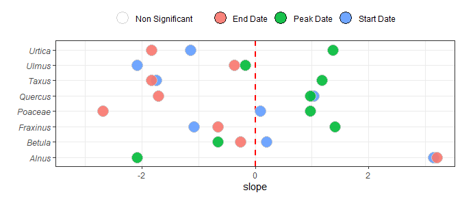

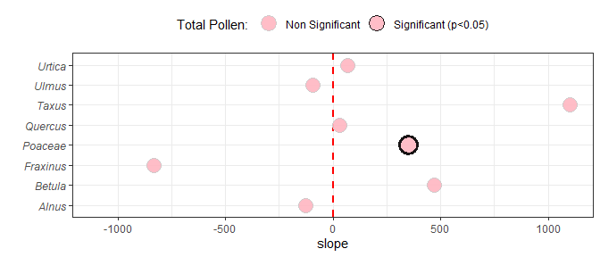

```r
analyse_trend(munich_pollen, interpolation = FALSE, export.result = FALSE, export.plot = FALSE, result="plot")
```

Lets see what happen if we don’t split the graphics:

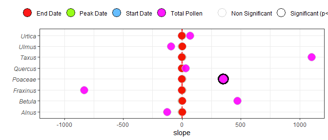

```r
analyse_trend(munich_pollen, interpolation = FALSE, export.result = FALSE, export.plot = FALSE, split = FALSE, quantil = 1, result="plot")
```

Now the results are less readable, but this kind of graphical representation may be interesting for some people. When plotting all the results together, it might be useful to exclude some outliers:

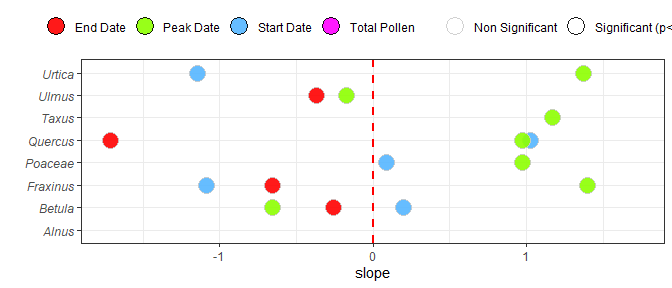

```r
analyse_trend(munich_pollen, interpolation = FALSE, export.result = FALSE, export.plot = FALSE, split=FALSE, quantil = 0.5, result="plot")
```

As you can appreciate, a lot of points have been omitted.

You can also change the significance level as mentioned above. Why don`t we try?:

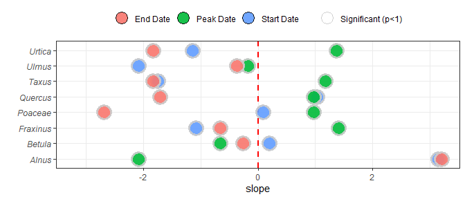

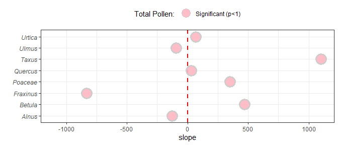

```r
analyse_trend(munich_pollen, interpolation = FALSE, export.result = FALSE, export.plot = FALSE, significant = 1, result = "plot")
```

Now everything is significant!

Have a look to the numbers by setting *result = “table”* (the default output).

```r
analyse_trend(munich_pollen, interpolation = FALSE, export.result = FALSE, export.plot = FALSE, significant = 1, result="table")
```

[output not shown]

**interpollen() function** is integrated in this function. Consult the “help” section of this function to use it.

If **result = “plot”**, the function returns a list of objects of class *ggplot2*; if **result = “table”**, the function returns a *data.frame*. By default, **result = “table”**.

# Function plot_trend()

The function **plot_trend()** has been created to calculate the main seasonal indexes of the pollen season (“Start Date”, “Peak Date”, “End Date” and “Pollen Integral”) and their trends analysis over the seasons. It produces plots showing the distribution of the main seasonal indexes over the years.

The **results are stored in two folders termed “plot_AeRobiology” and “table_AeRobiology”** which will be located in your working directory (only if `export.result = FALSE` & `export.plot = FALSE`).

```r
plot_trend(munich_pollen, interpolation = FALSE, export.plot = FALSE, export.result = FALSE)
```

**NOTE:** The plots are not shown in your R environment. Because of the high amount of graphs, they are stored in new folders created in your working directory (search were you have saved the R project and you will find the folders).

The **interval of confidence** only appears if more than 6 dots are plotted. If not, a line crossing all the dots is plotted.

**interpollen() function** is integrated in this function. Consult the “help” section of this function to use it.

# Function iplot_abundance()

The function **iplot_abundance()** generates a barplot based on the relative abundance in the air (as percentage) of each pollen/spore type with respect to the total amounts.

The main arguments are:

- **n.types:** A `numeric` (integer) value specifying the number of the most abundant pollen types that must be represented in the plot of the relative abundance. A more detailed information about the selection of the considered pollen types may be consulted [here](https://CRAN.R-project.org/package=AeRobiology). The `n.types` argument will be 15 types by default.
- **y.start/y.end:** A `numeric` (integer) value specifying the period selected to calculate relative abundances of the pollen types (start year - end year). If `y.start` and `y.end` are not specified (`NULL`), the entire database will be used to generate the pollen calendar. The `y.start` and `y.end` arguments will be `NULL` by default.
- **col.bar:** A `character` string specifying the color of the bars to generate the graph showing the relative abundances of the pollen types. The `color` argument will be #E69F00 by default, but any color may be selected.
- **type.plot:** A `character` string specifying the type of plot selected to show the plot showing the relative abundance of the pollen types. The implemented types that may be used are: “static” (generates a static ggplot object) and “dynamic” (generates a dynamic plotly object).
- **exclude:** A character string vector with the names of the pollen types to be excluded from the plot.
- Others…

```
## Ignoring unknown labels:
## * size : "14"
```

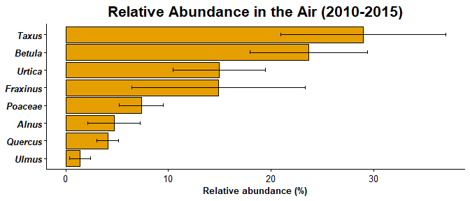

```r
iplot_abundance(munich_pollen, interpolation = FALSE, export.plot = FALSE, export.result = FALSE)
```

Now we are going to reduce the number of types:

```
## Ignoring unknown labels:
## * size : "14"
```

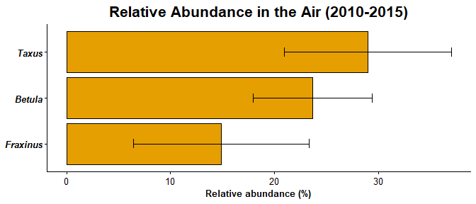

```r
iplot_abundance(munich_pollen, interpolation = FALSE, export.plot = FALSE, export.result = FALSE, n.types = 3)
```

We can also select the abundance for only one year and change the color:

```
## Ignoring unknown labels:
## * size : "14"
```

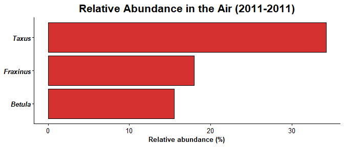

```r
iplot_abundance(munich_pollen, interpolation = FALSE, export.plot = FALSE, export.result = FALSE, n.types = 3, y.start = 2011, y.end = 2011, col.bar = "#d63131")
```

Furthermore, we can make it interactive:

```r
iplot_abundance(munich_pollen, interpolation = FALSE, export.plot = FALSE, export.result = FALSE, n.types = 3, y.start = 2011, y.end = 2011, col.bar = "#d63131", type.plot = "dynamic")
```

```
## Ignoring unknown labels:
## * size : "14"
```

**interpollen() function** is integrated in this function. Consult the “help” section of this function to use it.

# Function iplot_pheno()

The function **iplot_pheno()** generates a boxplot based on phenological parameters (start_dates and end_dates) which are calculated by the estimation of the main parameters of the pollen season. The main arguments are:

- **data**: A `data.frame` object including the general database where calculation of the pollen season must be applied in order to generate the phenological plot based on the start_dates and end_dates. This data.frame must include a first column in “Date” format and the rest of columns in “numeric” format belonging to each pollen type by column.
- **method**: A `character` string specifying the method applied to calculate the pollen season and the main parameters. The implemented methods that can be used are: “percentage”, “logistic”, “moving”, “clinical” or “grains”. A more detailed information about the different methods for defining the pollen season may be consulted in calculate_ps function.
- **n.types**: A `numeric` (integer) value specifying the number of the most abundant pollen types that must be represented. A more detailed information about the selection of the considered pollen types may be consulted [here](https://CRAN.R-project.org/package=AeRobiology). The `n.types` argument will be 15 by default.
- **type.plot**: A `character` string specifying the type of plot selected to show the phenological plot. The implemented types that may be used are: “static” (generates a static ggplot object) and “dynamic” (generates a dynamic plotly object).
- Other arguments related to **calculate_ps() function**

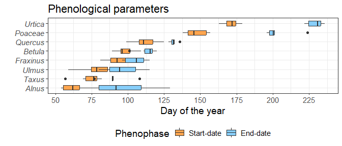

```r
iplot_pheno(munich_pollen, method= "percentage", perc=80, int.method="spline", n.types = 8)
```

We can change the method to establish the main pollen season and the number of pollen types to show:

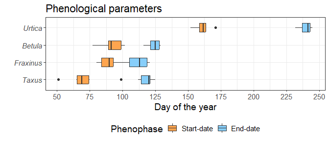

```r
iplot_pheno(munich_pollen, method= "clinical", n.clinical = 3, int.method="spline", n.types = 4)
```

Furthermore, we can make the plot interactive to obtain more information by clicking in each object:

```r
iplot_pheno(munich_pollen, method= "clinical", n.clinical = 3, int.method="spline", n.types = 4, type.plot = "dynamic")
```

# Function plot_ps()

The function **plot_ps() function** was designed to plot the main pollen season of a single pollen type and year. Some of the arguments are:

- **data**: A `data.frame` object including the general database where interpolation must be performed. This data.frame must include a first column in “Date” format and the rest of the columns in “numeric” format. Each column must contain information of one pollen type. It is not necessary to insert missing gaps, the function will automatically detect them.
- **pollen.type**: A `character` string specifying the name of the pollen type which will be plotted. The name must be exactly the same that appears in the column name. Mandatory argument with no default.
- **year**: A `numeric` (integer) value specifying the season to be plotted. The season does not necessary fit a natural year. See calculate_ps for more details. Mandatory argument with no default.
- **days**: A `numeric` (integer) specifying the number of days beyond each side of the main pollen season that will be represented. The `days` argument will be 30 by default.
- **fill.col**: A `character` string specifying the name of the color to fill the main pollen season in the plot. See ggplot function for more details. The `fill.col` argument will be “turquoise4” by default. It uses the ggplot color codes.
- **axisname**:A `character` string specifying the title of the y axis. By default, `axisname = expression(paste("Pollen grains / m"^"3"))`
- Others…

**calculate_ps function** is integrated in this function. Consult [here](https://CRAN.R-project.org/package=AeRobiology) for more information. **Interpolation is mandatory** for this function. Due to technical encoding, you must use interpollen function through calculate_ps function. Consult calculate_ps for more information.

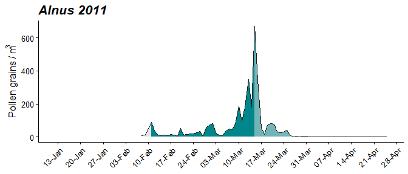

```r
plot_ps(munich_pollen, pollen.type="Alnus", year=2011)
```

If you misspell some pollen type name, the function will tell you:

```r
plot_ps(munich_pollen, pollen.type="Alnuscdscscr", year=2011)
```

```
## Error in `plot_ps()`:
## ! pollen.type: Please, insert only a pollen type which is in your database (type the exact name)
```

**Let`s test more arguments:**

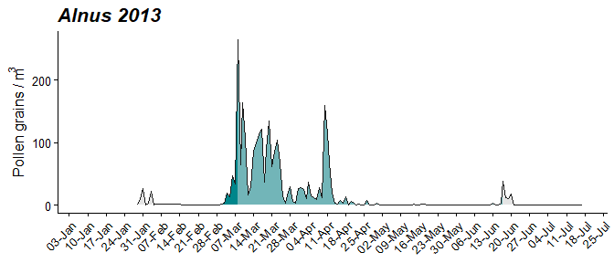

```r
plot_ps(munich_pollen, pollen.type="Alnus", year=2013, method= "percentage", perc=95 ,int.method = "lineal")
```

As you have noticed, the arguments `method`, `perc` and `int.method` are from **calculate_ps function**.

What about changing the interpolation method?

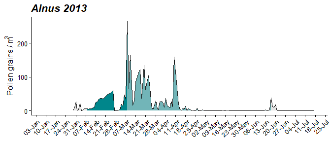

```r
plot_ps(munich_pollen, pollen.type="Alnus", year=2013, method= "percentage", perc=95 ,int.method = "movingmean")
```

Do you want a larger scale?

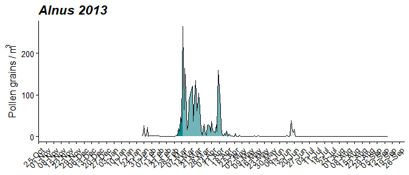

```r
plot_ps(munich_pollen, pollen.type="Alnus", year=2013, days = 90)
```

Maybe a different color and y-axis name?

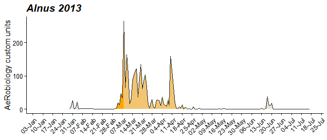

```r
plot_ps(munich_pollen, pollen.type="Alnus", year=2013, fill.col = "orange", axisname = "AeRobiology custom units")
```

# Function plot_hour()

Please keep in mind that the function *plot_hour()* is only available after package **version 2.0**.

The input data must be a data.frame object with the structure long. Where the first two columns are factors indicating the pollen and the location. The 3 and 4 columns are POSIXct, showing the date with the hour. Where the third column is the beginning of the concentration *from* and the fourth column is the end time of the concentration data *to*. The fifth column shows the concentrations of the different pollen types as numeric. Please see the example 3-hourly data from the automatic pollen monitor BAA500 from Munich and Viechtach in Bavaria (Germany) data(“POMO_pollen”), supplied by ePIN Network supported by the Bavarian Government.

We will load an example dataset about 3-hourly data from the ePIN network in Bavaria (Germany). The dataset contains information of 3-hourly concentrations of pollen in the atmosphere of Munich (DEBIED) and Viechtach (DEVIEC) during the year 2018. Pollen types included: “Poaceae” and “Pinus”.

The data were obtained by the automatic pollen monitor BAA500 from Munich and Viechtach in Bavaria (Germany) data(“POMO_pollen”), supplied by the public ePIN Network supported by the Bavarian Government. The ePIN Network was built by Das Bayerische Landesamt für Gesundheit und Lebensmittelsicherheit (LGL) in collaboration with Zentrum Allergie und Umwelt (ZAUM).

```r
data("POMO_pollen")
```

The function plots pollen data expressed in concentrations with time resolution higher than 1 day (e.g. hourly, bi-hourly concentrations). If the argument *result = “plot”*, the function returns a list of objects of class **ggplot2**; if *result = “table”*, the function returns a **data.frame** with the hourly patterns.

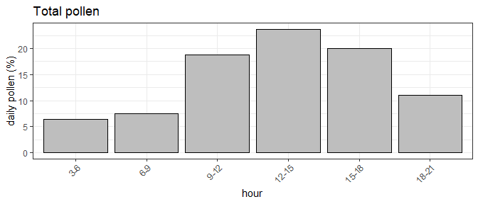

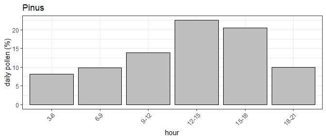

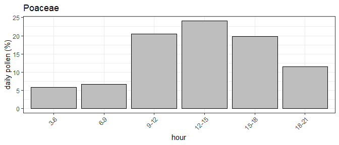

```r
plot_hour(POMO_pollen)
```

To display a table we have to set the argument *result = “table”*.

3-Hourly patterns

| pollen | location | from | to | value | date | hour | hour2 | Hour | percent |
| --- | --- | --- | --- | --- | --- | --- | --- | --- | --- |
| Pinus | DEVIEC | 2018-05-09 03:00:00 | 2018-05-09 06:00:00 | 276.6 | 2018-05-09 | 3 | 6 | 3-6 | 12.5 |
| Pinus | DEVIEC | 2018-05-10 03:00:00 | 2018-05-10 06:00:00 | 99.9 | 2018-05-10 | 3 | 6 | 3-6 | 4.9 |
| Pinus | DEVIEC | 2018-05-11 03:00:00 | 2018-05-11 06:00:00 | 52.5 | 2018-05-11 | 3 | 6 | 3-6 | 3.6 |
| Pinus | DEVIEC | 2018-05-12 03:00:00 | 2018-05-12 06:00:00 | 195.3 | 2018-05-12 | 3 | 6 | 3-6 | 9.2 |
| Pinus | DEVIEC | 2018-05-13 03:00:00 | 2018-05-13 06:00:00 | 24.0 | 2018-05-13 | 3 | 6 | 3-6 | 1.5 |
| Pinus | DEVIEC | 2018-05-14 03:00:00 | 2018-05-14 06:00:00 | 85.8 | 2018-05-14 | 3 | 6 | 3-6 | 5.2 |
| Pinus | DEVIEC | 2018-05-15 03:00:00 | 2018-05-15 06:00:00 | 104.7 | 2018-05-15 | 3 | 6 | 3-6 | 17.0 |
| Pinus | DEVIEC | 2018-05-16 03:00:00 | 2018-05-16 06:00:00 | 33.3 | 2018-05-16 | 3 | 6 | 3-6 | 20.6 |
| Pinus | DEVIEC | 2018-05-17 03:00:00 | 2018-05-17 06:00:00 | 19.1 | 2018-05-17 | 3 | 6 | 3-6 | 8.7 |
| Pinus | DEVIEC | 2018-05-18 03:00:00 | 2018-05-18 06:00:00 | 57.2 | 2018-05-18 | 3 | 6 | 3-6 | 7.3 |

We can also split the different stations by setting the argument *locations = TRUE*.

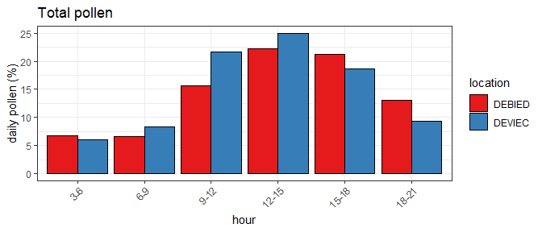

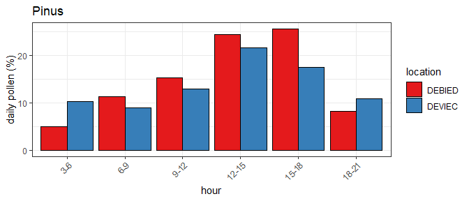

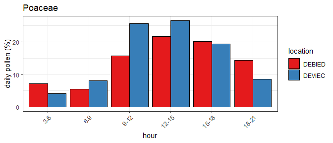

```r
plot_hour(POMO_pollen, locations = TRUE)
```

# Function plot_heathour()

An alternative to *plot_hour()* is *plot_heathour()*, which shows a summary of all particles with a heatplot. The input data should have the same format as for *plot_hour()*.

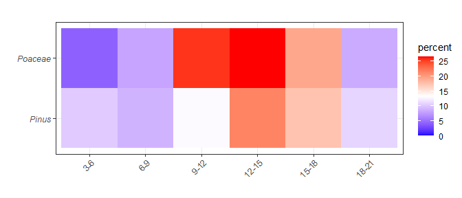

```r
plot_heathour(POMO_pollen)
```

You can also set the colors by the arguments: *low.col*, *mid.col* and *high.col*. E.g.

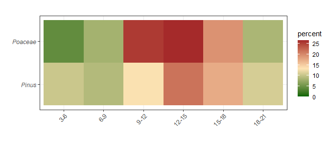

```r
plot_heathour(POMO_pollen, low.col = "darkgreen", mid.col = "moccasin", high.col = "brown")
```

By setting *locations = TRUE* you can split the result by locations:

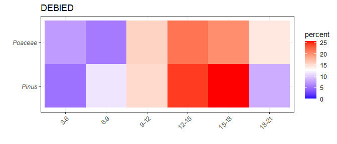

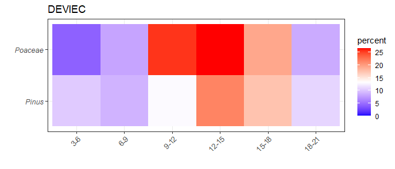

```r
plot_heathour(POMO_pollen, locations = TRUE)
```

[^1]: University of Castilla-La Mancha & ZAUM (TUM/Helmholtz Zentrum)
[^2]: University of Malaga
[^3]: Zentrum Allergie und Umwelt - ZAUM (TUM/Helmholtz Zentrum)